# Session 3: Analysis of transcriptomes

Rubén Sancho, Bruno Contreras Moreira

Estación Experimental de Aula Dei-CSIC, Zaragoza, Spain

# 1 Introduction

In this session we will continue annotating sequences, but now with a focus on transcripts, which can be coding and non-coding. In fact, the same gene can encode both coding and non-coding transcripts (Poliseno, Lanza, and Pandolfi 2024):

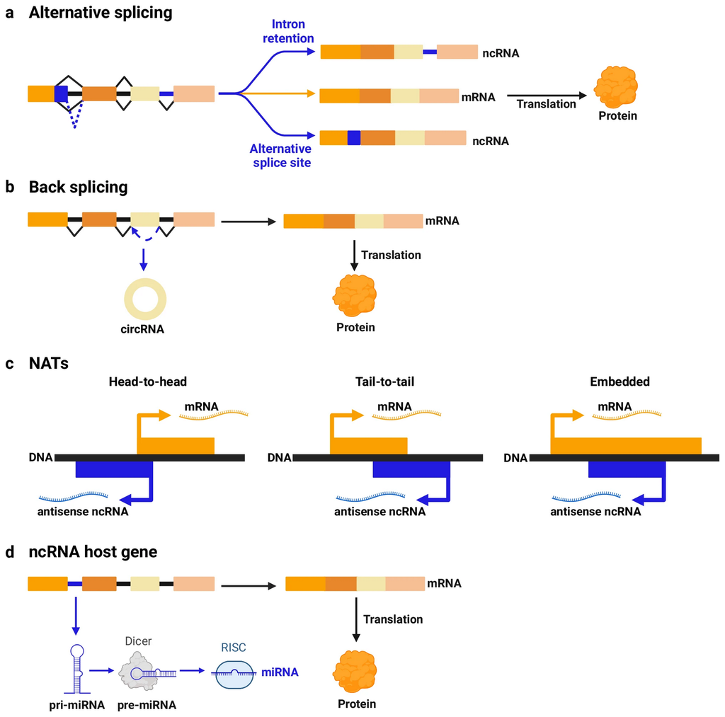

# 2 Transcript-based pangenome analysis

We will follow the introduction and protocol at:

https://eead-csic-compbio.github.io/get_homologues/plant_pangenome/protocol.html

Note that the software GET_HOMOLOGUES-EST is a part of the GET_HOMOLOGUES package, which you installed in session 2.

# 3 Coexpression network analysis

The files needed this for this session are:

- Analysis_Transcriptomes_RS_IAMZ2025_v3.pdf
- Practical_Sleuth.Rmd
- Practical_WGCNA_D_dataset.Rmd
- Practical_WGCNA_W_dataset.Rmd
- Readme_Docker_Transcriptomic_class.txt

Note that Rmd files are to be opened with Rstudio.

## 3.1 Your report

Please make a folder named ‘transcripts/’ in the same GitHub repo of [session 1](https://eead-csic-compbio.github.io/bioinformatics/session1.html), and write a brief report. See more recommendations [here](https://eead-csic-compbio.github.io/bioinformatics).

- If you did the pantranscriptome analysis the report should include:
  - A simulation of pan leaf pantranscriptome after comparing 14 barleys, similar to Fig. 6 in the GET_HOMOLOGUES-EST protocol
  - A table of Pfam domains enriched in core and accessory transcripts
  - An overall recapitulation of the analysis.
- If you perform the co-expression network analysis, it should include:
  - How you solved the exercises.
  - The results obtained.
  - The main specific inputs and outputs used at each step.
  - The problems you encountered.
  - Briefly propose an experiment in which these analyses could be applied.

# Bibliography

Poliseno, Laura, Martina Lanza, and Pier Paolo Pandolfi. 2024. “Coding, or Non-Coding, That Is the Question.” *Cell Research* 34 (9): 609—629. https://doi.org/10.1038/s41422-024-00975-8.